# census_tract_location_matching

Claire Morton

10/2/2022

## Intro

I noticed some mismatches between CES tract labels and actual census tract labels. Needless to say, this is an issue, so I’m making this document to explore and make sure that I have the right tracts for matching the external census data to CES 4.0 scores in order to make a CES recalculated score.

```r
tract <- tracts(
  state = "CA",
  year = 2019
) %>%
  select(STATEFP, COUNTYFP, TRACTCE, GEOID, geometry)
tract_137000_2019 <- tract %>%
  filter(TRACTCE == "137000")
tract_800204_2019 <- tract %>%
  filter(TRACTCE == "800204")
```

```r
tract_2010 <- tracts(
  state = "CA",
  year = 2010
)
tract_800204_2010 <- tract_2010 %>%
  filter(TRACTCE10 == "800204")
tract_930401_2010 <- tract_2010 %>%
  filter(TRACTCE10 == "930401")
```

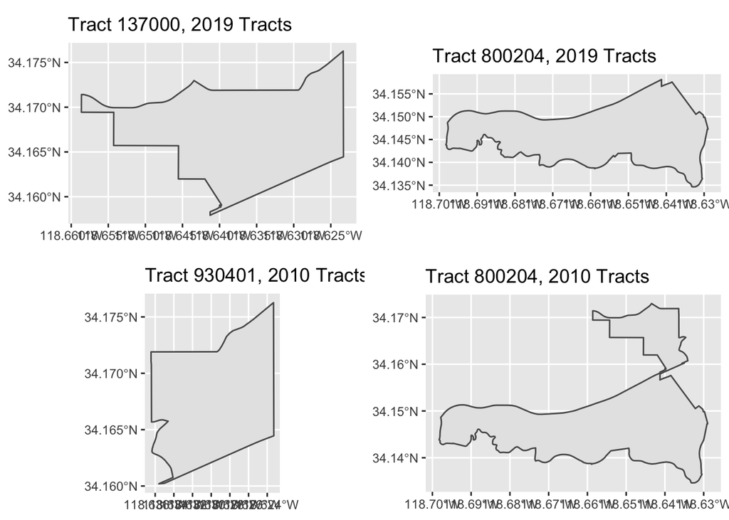

```r
map_a <- ggplot(tract_137000_2019) +
  geom_sf() +
  ggtitle ("Tract 137000, 2019 Tracts")
map_b <- ggplot(tract_800204_2019) +
  geom_sf() +
  ggtitle ("Tract 800204, 2019 Tracts")
map_c <- ggplot(tract_930401_2010) +
  geom_sf() +
  ggtitle ("Tract 930401, 2010 Tracts")
map_d <- ggplot(tract_800204_2010) +
  geom_sf() +
  ggtitle ("Tract 800204, 2010 Tracts")
ggarrange (map_a, map_b, map_c, map_d)
```

The census released a statement (https://www2.census.gov/geo/pdfs/reference/Geography_Notes.pdf, page 6) that tract 137000 was erroneously deleted from the 2010 census. So I think what happened is that CES used the 2010 CES tracts, with the tract error, to create CES. This explains why they have tract 800204 and 930401 in the way shown in the 2010 data. But, when I pulled tract data, I used 2019 (tracts shouldn’t have changed from 2010-2019). But they had changed, because the census caught their mistake.

In 2010, tract “930401” and teh top half of tract “800204” were split up. They should be one tract, tract 137000. But tract 137000 was deleted in the 2010 census. This split means that CES erroneously relates the data in actual tract 137000 to just a part of that tract (which it labels 930401), and it includes only the data from actual tract 800204 in an area it says includes some of actual tract 137000, which CES calls tract 800204. This mistake means that while CES and the census have the same *number* of tracts from 2010-2019, their *makeup* is different geographically.

Indeed, the above document states: tract 137000 was erroneously deleted, tract 930401 should be entirely in tract 137000 (and shouldn’t exist), and tract 800204 erroneously contains some of tract 137000.

This mistake in the census, which propagated to CES, means that their *map* is incorrect. However, the *data* is fine. Tract 930401 in CES data contains the exact right data for actual tract 137000 (population of 5067 in both CES data and my pulled data from the 2019 ACS 5-year summary), and the CES tract 800204 contain the correct data for actual tract 800204 (population of 4495 in both CES data and my pulled data from 2019 ACS 5-year summary). So the fix that I need to make is, in the CES data, to rename tract 930401 to be tract 137000, and keep tract 800204 as is, and, when I create maps of the original or recalculated CES, to be sure to use 2019 census tracts.

```r
setdiff(tract_2010$TRACTCE10, tract$TRACTCE)
```

```
## [1] "930401"
```

```r
setdiff(tract$TRACTCE, tract_2010$TRACTCE10)
```

```
## [1] "137000"
```